# Newsom analysis

Jen

1/3/2020

## Topline numbers

**How Newsom ranks by number of Tweets between 3-01-2019 and 12-31-2019**

- compared to other governors’ personal accounts: **@GavinNewsom ranked 5th**
- compared to other governors’ personal OR official accounts: **@GavinNewsom ranked 14th (his official account ranked 8th)**
- compared to tweets from other governors’ personal AND official accounts: **Newsom/CA ranked 2nd**

**How Newsom ranks vs other governors when tweeting about Trump**

- compared to other governors’ personal accounts: **@GavinNewsom ranked 3rd**
- compared to other governors’ personal OR official accounts: **@GavinNewsom ranked 3rd (his official account ranked 5th)**
- compared to tweets from other governors’ personal AND official accounts: **Newsom/CA ranked 3rd**

## An analysis of Governor Gavin Newsom’s tweeting habits

Gavin Newsom is California’s first social media governor. He has the distinction of being the most followed U.S. governor on Twitter – by a lot.

|  | name | screen_name | followers_count |
| --- | --- | --- | --- |
| 1 | Gavin Newsom | GavinNewsom | 1474583 |
| 2 | Andrew Cuomo | NYGovCuomo | 861054 |
| 3 | Ron DeSantis | GovRonDeSantis | 386705 |
| 4 | Greg Abbott | GregAbbott_TX | 329118 |
| 5 | Charlie Baker | MassGovernor | 244702 |
| 6 | Gov. Greg Abbott | GovAbbott | 190253 |
| 7 | Steve Bullock | GovernorBullock | 188798 |
| 8 | Ron DeSantis | RonDeSantisFL | 180717 |
| 9 | Governor Jay Inslee | GovInslee | 179060 |
| 10 | Ralph Northam | GovernorVA | 150388 |

[output cut: 71 more lines]

So we decided to learn more about Newsom’s tweeting habits.

We used a Twitter API to collect tweets from all U.S. governors’ accounts, official and personal, between March 1 and December 31, 2019. This is as far back as we could go using the API and still analyze a complete set of governors’ tweets. We were able to collect older tweets going back to January 1, 2017 for Gavin Newsom’s personal account.

We studied Governor Newsom’s tweeting habits–how he tweets between his two accounts and compared to other U.S. Governors. Here’s what we found:

## Newsom’s tweeting habits

Gavin Newsom has two accounts: an official account, @CAgovernor, and a personal account, @GavinNewsom.

#### Which @GavinNewsom tweets received the most likes in the past 3 years?

|  | created_at | screen_name | text | favorite_count |
| --- | --- | --- | --- | --- |
| 1 | 2017-06-02T22:33:21Z | GavinNewsom | This is from an Australian news outlet. https://t.co/yjmj7SzXRk | 163825 |
| 2 | 2019-08-04T00:11:22Z | GavinNewsom | If you’re so “horrified”... do something about it. https://t.co/jl4GxfvPWJ | 118724 |
| 3 | 2017-09-23T17:05:42Z | GavinNewsom | RECAP: Nazis: very fine people Racist sheriff: unfairly treated Black athletes exercising 1A rights: sons of b****** and uninvited to WH. | 82361 |
| 4 | 2018-03-07T17:01:52Z | GavinNewsom | Jeff Sessions just called me an embarrassment. A man whose legacy is targeting immigrants, re-waging the failed War on Drugs, sucking-up to private prison profiteers, and apologizing for white suprema… | 72862 |
| 5 | 2019-07-25T23:02:40Z | GavinNewsom | TODAY: Trump chooses to resume the death penalty, CA halts it. Trump tries to roll back auto emission standards, CA strikes a deal directly w/car companies to protect them. Trump tries to eliminate th… | 70975 |
| 6 | 2017-11-20T00:06:33Z | GavinNewsom | Can’t believe I have to type these words: A president should never be willing to leave US citizens in a foreign jail of a non-democratic regime solely because they aren’t praising him enough. https://… | 59417 |
| 7 | 2017-11-05T21:40:28Z | GavinNewsom | They were in their church praying when this happened. What they need is gun control. https://t.co/2DfSoaoJ28 | 56584 |
| 8 | 2019-08-08T20:56:39Z | GavinNewsom | "Please don't leave the childs with cryingness and everything...I need my dad by me." Watch this. Ask yourself what we're doing. What we're tolerating. What we stand for. There are many complicated is… | 50049 |
| 9 | 2019-08-03T21:52:05Z | GavinNewsom | Again. On Sunday, it was Gilroy. Today, it’s El Paso. Our malls. Our festivals. Our concerts. Our churches. Our synagogues. Our movie theaters. Our classrooms. Our homes. This is an epidemic. This is … | 48230 |
| 10 | 2018-05-14T17:54:35Z | GavinNewsom | Hi @NRA - Received your questionnaire. Not sure what gave you the impression I would ever WANT your endorsement. Or your money. Look forward to the day you're swept into the compost bin of history. Un… | 46114 |

[output cut: 3907 more lines]

#### Which Gavin Newsom FB post had the most reactions (*unlike Twitter likes, the reactions can also be negative) in the past year?

|  | date | text | reactions_cleaned | shares_cleaned | comments_cleaned |
| --- | --- | --- | --- | --- | --- |
| 1 | 8/3/19 |  | 37000 | 17000 | 770 |
| 2 | 1/13/19 | The science is unanimous: expanding paid family leave will mean a better life for our kids, our workers, our economy, and our future. It’s not just the right thing to do — it’s a developmental necessi… | 36000 | 4800 | 330 |
| 3 | 1/18/19 | We’re not going to back down to threats from this administration. While leaders in Washington might not be doing their job, federal workers who are vital to keeping our country running and safe are do… | 25000 | 12000 | 290 |
| 4 | 1/10/19 | Beyond proud of you, Jennifer Siebel Newsom!! You’ve never accepted the status quo. Women across our country have demanded change, catalyzing cultural transformation so that everyone, regardless of ge… | 22000 | 2200 | 240 |
| 5 | 6/17/19 | For the first time in our state’s history, the Pride flag has been raised at our State Capitol!! | 20000 | 1900 | 430 |
| 6 | 11/3/19 | Still waiting for our rakes to arrive. | 19000 | 2400 | 640 |
| 7 | 10/6/19 | Never gets old. | 18000 | 3700 | 340 |
| 8 | 2/11/19 | The border ‘emergency’ is a manufactured crisis, and CA’s National Guard will not be part of this political theater. | 18000 | 4000 | 520 |
| 9 | 10/13/19 | When parents can’t afford to buy their kids the typical school lunch, the students are sometimes denied food or given a different, cheaper alternative. Lunch shaming is very real and has serious conse… | 16000 | 2800 | 310 |
| 10 | 1/25/19 |  | 16000 | 5200 | 270 |

[output cut: 387 more lines]

He has far more audience engagement from Twitter likes than Facebook reactions.

#### Which @GavinNewsom tweets were retweeted the most?

|  | created_at | screen_name | text | retweet_count |
| --- | --- | --- | --- | --- |
| 1 | 2018-02-22T22:50:03Z | GavinNewsom | Young people have helped lead all our great movements. How inspiring to see it again in so many smart, fearless students standing up for their right to be safe; marching and organizing to remake the w… | 426851 |
| 2 | 2017-07-20T00:50:57Z | GavinNewsom | John McCain is an American hero &amp;amp; one of the bravest fighters I've ever known. Cancer doesn't know what it's up against. Give it hell, John. | 388117 |
| 3 | 2017-09-05T18:57:53Z | GavinNewsom | To target hopeful young strivers who grew up here is wrong, because they’ve done nothing wrong. My statement: https://t.co/TCxZdld7L4 | 362238 |
| 4 | 2017-06-01T02:08:02Z | GavinNewsom | People in covfefe houses shouldn't throw covfefe. https://t.co/M7oK5Z6qwF | 288817 |
| 5 | 2017-07-10T13:24:32Z | GavinNewsom | Good morning Mr. President. It would never have occurred to my mother or my father to ask me. Were you giving our country away? Hoping not. https://t.co/4ODjWZUp0c | 174329 |
| 6 | 2017-11-01T19:06:12Z | GavinNewsom | Starting today, you can sign up for 2018 health coverage. Head on over to https://t.co/ob1Ynoesod and find a plan that meets your needs. https://t.co/6vYt83w74T | 129992 |
| 7 | 2017-01-20T15:44:41Z | GavinNewsom | Yes we can. Yes we did. Thank you for being a part of the past eight years. https://t.co/mjmr4RkxpV | 129639 |
| 8 | 2017-09-13T19:00:32Z | GavinNewsom | Our silence on this is embarrassing. https://t.co/Sq1PL3lpkS | 126258 |
| 9 | 2018-06-18T20:27:20Z | GavinNewsom | Sometimes truth transcends party. https://t.co/TeFM7NmNzU | 126159 |
| 10 | 2017-09-24T21:35:07Z | GavinNewsom | Patriotism isn't about making everyone stand and salute the flag. Patriotism is about making this a country where everyone wants to. | 125673 |

[output cut: 3907 more lines]

[output not shown]

[output cut: 387 more lines]

Gavin Newsom also has more audience engagement from Twitter retweets than from Facebook shares.

- reply count data not available without Premium and Enterprise tier

#### Which Twitter users does @GavinNewsom reply to the most?

|  | reply_to_screen_name | n |
| --- | --- | --- |
| 1 |  | 3530 |
| 2 | GavinNewsom | 182 |
| 3 | yldja | 6 |
| 4 | Arborsierra77 | 3 |
| 5 | ColeDavid | 3 |
| 6 | DarrinFisher2 | 3 |
| 7 | JenSiebelNewsom | 3 |
| 8 | _SilenceDo_good | 2 |
| 9 | bobbychandlerjr | 2 |
| 10 | Brandontheblade | 2 |

[output cut: 168 more lines]

* @yldja’s Twitter bio reads, [“The OC, state of Commiefornia”] (https://twitter.com/yldja)

#### Which Twitter users does @GavinNewsom mention the most?

|  | mentions_screen_name | n |
| --- | --- | --- |
| 1 |  | 2573 |
| 2 | GOP | 106 |
| 3 | JenSiebelNewsom | 103 |
| 4 | realDonaldTrump | 58 |
| 5 | NRA | 51 |
| 6 | POTUS | 33 |
| 7 | KamalaHarris | 22 |
| 8 | CAgovernor GavinNewsom | 21 |
| 9 | SpeakerRyan | 20 |
| 10 | CAgovernor | 16 |

[output cut: 680 more lines]

*[@JenSiebelNewsom is Gavin Newsom's wife] (https://twitter.com/JenSiebelNewsom)

#### What are @GavinNewsom’s favorite hashtags? (He doesn’t use many)

|  | screen_name | hashtags | n |
| --- | --- | --- | --- |
| 1 | GavinNewsom |  | 3464 |
| 2 | GavinNewsom | BlueCA | 9 |
| 3 | GavinNewsom | MarchingForward | 9 |
| 4 | GavinNewsom | CADEM2017 | 8 |
| 5 | GavinNewsom | CaliforniaForAll | 8 |
| 6 | GavinNewsom | CADEM19 | 7 |
| 7 | GavinNewsom | WomensMarch | 7 |
| 8 | GavinNewsom | IStandWithPP | 6 |
| 9 | GavinNewsom | OrovilleDam | 6 |
| 10 | GavinNewsom | Trumpcare | 6 |

[output cut: 290 more lines]

#### By comparison, theses are Gavin Newsom’s official account’s favorite hashtags:

|  | screen_name | hashtags | n |
| --- | --- | --- | --- |
| 1 | CAgovernor |  | 1535 |
| 2 | CAgovernor | CaliforniaForAll | 221 |
| 3 | CAgovernor | CalEITC | 10 |
| 4 | CAgovernor | CalEITC CaliforniaForAll | 10 |
| 5 | CAgovernor | DiaTogether CaliforniaForAll | 8 |
| 6 | CAgovernor | WildfirePreparednessWeek | 6 |
| 7 | CAgovernor | 2020Census CaliforniaForAll | 5 |
| 8 | CAgovernor | 2020census CaliforniaForAll | 4 |
| 9 | CAgovernor | CaliforniaForAll CAbudget | 4 |
| 10 | CAgovernor | DiaDeLosNinos | 4 |

[output cut: 139 more lines]

We graphed the number of tweets Gavin Newsom posted each month from each of his accounts. He tweets more overall from his official account, @CAGovernor, which is run by his staff.

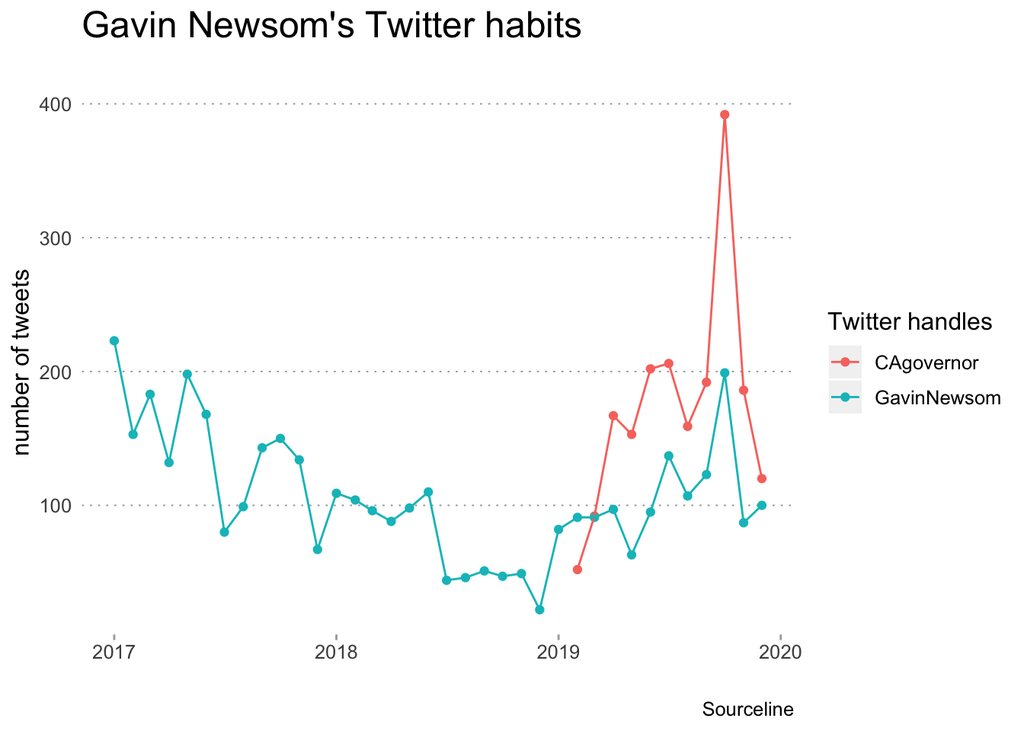

However, Newsom’s personal account mentions Trump more often, either directly via @DonaldJTrump or without Trump’s handle, than his official account.

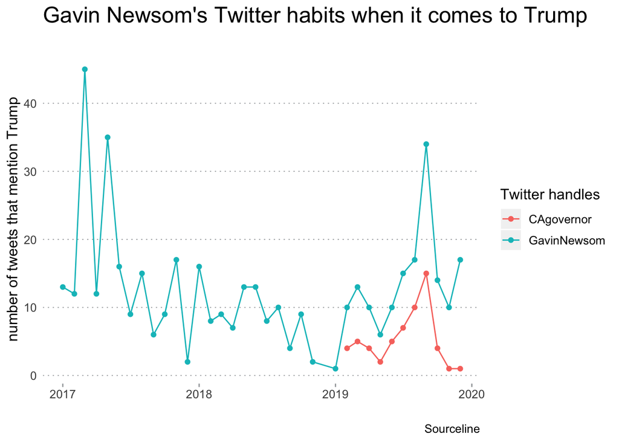

Gavin Newsom also tweets more frequently about Trump from his personal account.

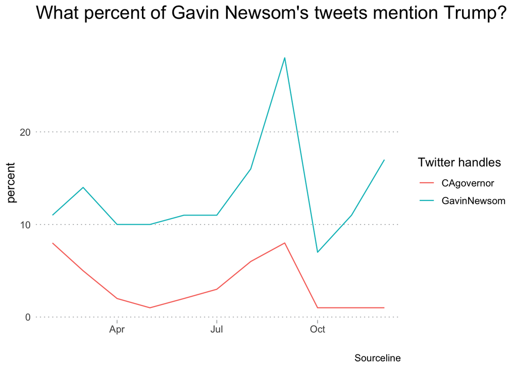

## How does Gavin Newsom’s Twitter habits compare to other U.S. governors?

For this analysis, we looked at a 10-month time period between 03-01-2019 and 12-31-2019, which is as far back as we could go using the Twitter API and still gather a full set of data for all U.S. govenors.

Gavin Newsom’s personal account ranks 5th in number of tweets compared to other governors’ personal Twitter account.

|  | name.x | screen_name | tweets |
| --- | --- | --- | --- |
| 1 | Jay Inslee | JayInslee | 3695 |
| 2 | Doug Ducey | dougducey | 2904 |
| 3 | Steve Bullock | GovernorBullock | 2633 |
| 4 | Gov. Pete Ricketts | GovRicketts | 1645 |
| 5 | Gavin Newsom | GavinNewsom | 1099 |
| 6 | Phil Bryant | PhilBryantMS | 1090 |
| 7 | Greg Abbott | GregAbbott_TX | 961 |
| 8 | Governor David Ige | GovHawaii | 952 |
| 9 | John Bel Edwards | JohnBelforLA | 948 |
| 10 | Steve Sisolak | SteveSisolak | 946 |

[output cut: 36 more lines]

Gavin Newsom’s personal account ranks 14th in number of tweets compared to other governors’ personal or official Twitter acounts. He is outpaced by his official account, @CAgovenor, which has tweeted 1.7 times more in this same time period.

|  | screen_name | tweets |
| --- | --- | --- |
| 1 | JayInslee | 3695 |
| 2 | dougducey | 2904 |
| 3 | GovernorBullock | 2633 |
| 4 | GovMurphy | 2315 |
| 5 | LouisianaGov | 2015 |
| 6 | GovParsonMO | 1953 |
| 7 | GovernorTomWolf | 1928 |
| 8 | CAgovernor | 1869 |
| 9 | GovNedLamont | 1776 |
| 10 | GovRicketts | 1645 |

[output cut: 71 more lines]

And if we looked at which governor tweeted the most overall (from their official and personal accounts), Newsom becomes the second most prolific tweeting governor on Twitter in this time period.

|  | state | tweets |
| --- | --- | --- |
| 1 | WA | 4496 |
| 2 | CA | 2968 |
| 3 | LA | 2963 |
| 4 | AZ | 2904 |
| 5 | MT | 2633 |
| 6 | NJ | 2490 |
| 7 | NV | 2348 |
| 8 | MO | 2115 |
| 9 | PA | 1932 |
| 10 | CT | 1785 |

[output cut: 40 more lines]

Now let’s look at which governor tweeted the most to or about Trump in this same time period.

If we looked at only governors’ personal Twitter accounts, Gavin Newsom ranks third in number of Trump-related tweets.

|  | screen_name | trump_tweets | name.x | tweets | frequency_trump_tweets |
| --- | --- | --- | --- | --- | --- |
| 1 | GovernorBullock | 453 | Steve Bullock | 2633 | 17.2047094568933 |
| 2 | JayInslee | 318 | Jay Inslee | 3695 | 8.60622462787551 |
| 3 | GavinNewsom | 146 | Gavin Newsom | 1099 | 13.2848043676069 |
| 4 | PhilBryantMS | 50 | Phil Bryant | 1090 | 4.58715596330275 |
| 5 | GovRicketts | 46 | Gov. Pete Ricketts | 1645 | 2.79635258358663 |
| 6 | RonDeSantisFL | 37 | Ron DeSantis | 618 | 5.98705501618123 |
| 7 | JohnBelforLA | 22 | John Bel Edwards | 948 | 2.32067510548523 |
| 8 | OregonGovBrown | 17 | Governor Kate Brown | 664 | 2.56024096385542 |
| 9 | GovernorLittle | 16 | Brad Little | 566 | 2.82685512367491 |
| 10 | WVGovernor | 16 | Governor Jim Justice | 665 | 2.40601503759399 |

[output cut: 36 more lines]

This is what it looks like visually:

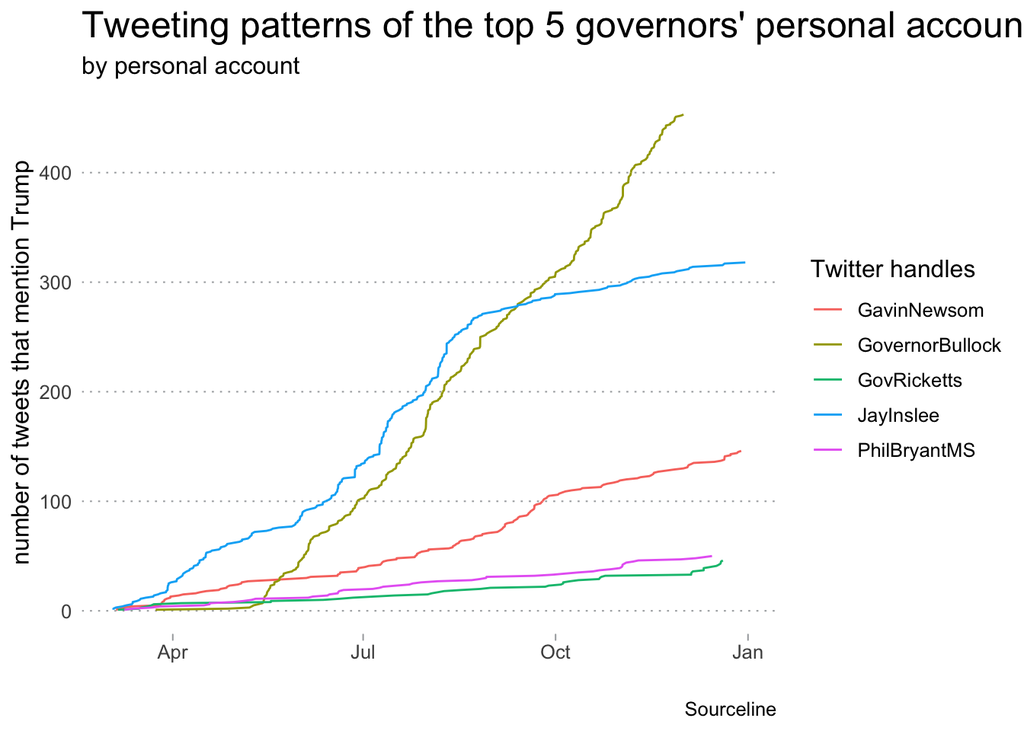

If we considered which governors’ personal or official Twitter account tweeted the most about Trump, Gavin Newsom’s personal account still ranks third. His official account ranks fifth.

|  | screen_name | trump_tweets | tweets | frequency_trump_tweets |
| --- | --- | --- | --- | --- |
| 1 | GovernorBullock | 453 | 2633 | 17.2047094568933 |
| 2 | JayInslee | 318 | 3695 | 8.60622462787551 |
| 3 | GavinNewsom | 146 | 1099 | 13.2848043676069 |
| 4 | GovInslee | 71 | 801 | 8.86392009987516 |
| 5 | CAgovernor | 54 | 1869 | 2.8892455858748 |
| 6 | GovRonDeSantis | 53 | 971 | 5.45829042224511 |
| 7 | NYGovCuomo | 53 | 817 | 6.48714810281518 |
| 8 | PhilBryantMS | 50 | 1090 | 4.58715596330275 |
| 9 | GovRicketts | 46 | 1645 | 2.79635258358663 |
| 10 | GovMurphy | 45 | 2315 | 1.9438444924406 |

[output cut: 71 more lines]

Here’s what that looks like visually:

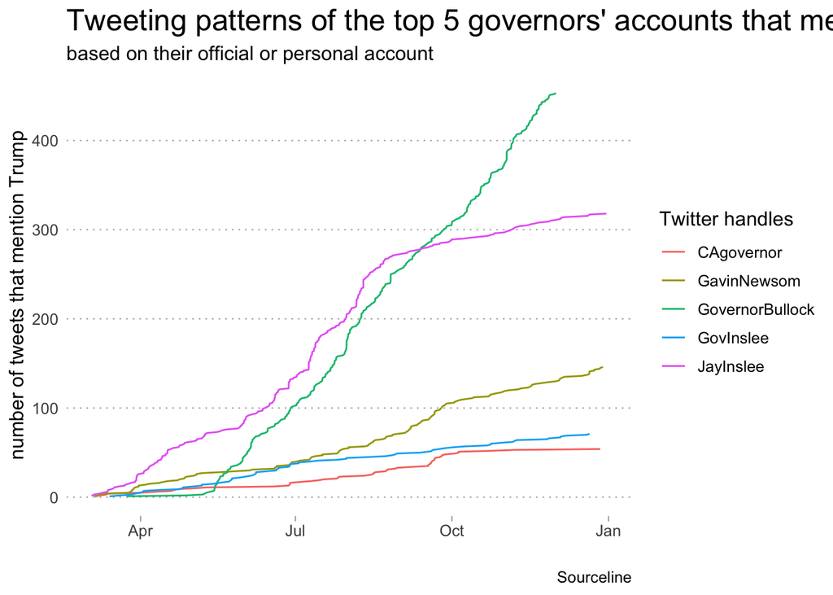

If we considered which governor tweeted about Trump from their official and pesonal accounts, Gavin Newsom still ranks third overall.

|  | state | trump_tweets | tweets | frequency_trump_tweets |
| --- | --- | --- | --- | --- |
| 1 | MT | 453 | 2633 | 17.2047094568933 |
| 2 | WA | 389 | 4496 | 8.65213523131673 |
| 3 | CA | 200 | 2968 | 6.73854447439353 |
| 4 | FL | 90 | 1589 | 5.66393958464443 |
| 5 | NJ | 53 | 2490 | 2.1285140562249 |
| 6 | NY | 53 | 818 | 6.47921760391198 |
| 7 | MS | 50 | 1090 | 4.58715596330275 |
| 8 | NE | 46 | 1645 | 2.79635258358663 |
| 9 | SD | 42 | 1370 | 3.06569343065693 |
| 10 | LA | 36 | 2963 | 1.21498481268984 |

[output cut: 40 more lines]

Here’s what that looks like visually:

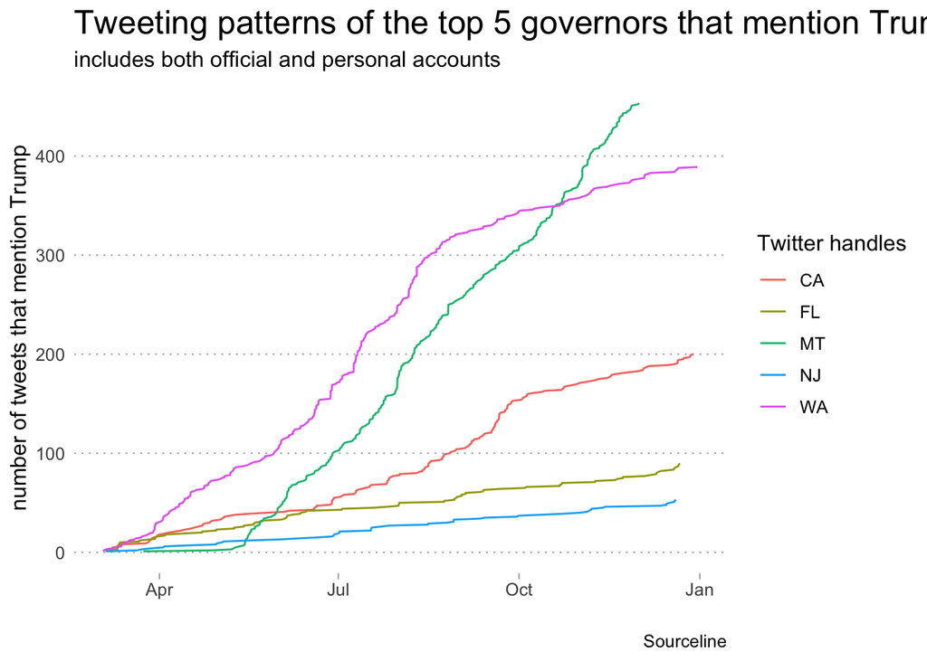